# Master SQL for Data Science Tutorial Notebook

By: Armando Vela

## Purpose of Notebook:

This notebook will be used to keep track of relevant queries that explain the concept discussed for each section within the tutorial. Just as an FYI, in the event the output produced is too large, a LIMIT clause will be added to save space. Furthermore, since the code snippets are associated to a Python package, the SQL code highlighting and commenting will be slightly different when compared to a PGAdmin interface.

Also, I plan to execute the code within the PGAdmin software environment and then place relevant code within this notebook so that I could add notes or helpful hints for each section.

With that said, I am hoping to learn/solidify my knowledge in the following areas:

- **SQL Query Basics**
  - SELECT Statement
  - WHERE Clause
  - AND & OR
  - Filtering Operators
  - ORDER BY
  - LIMIT
  - DISTINCT
  - Renaming Columns
- **Functions**
- **Grouping Data and Computing Aggregates**
  - GROUP BY Clause
  - HAVING Clause
- **Subqueries**
- **CASE Clause**
- **Correlated Subqueries**
- **Table Joins**
  - INNER and OUTER Joins
  - UNION, UNION ALL and EXCEPT Clauses
- **Window Functions for Analytics**

*Reference_1: Master SQL for Data Science on Udemy by Imtiaz Ahmad (Senior Software Engineer & Trainer @ Job Ready Programmer)*  
*Reference_2: For additional research on SQL code snippets, [w3schools.com](https://www.w3schools.com/sql/default.asp) was used.*  
*Additional_References: In the event additional sites need to be referenced, they will be placed within the appropriate section in the notebook below.*

## Load necessary packages & Connect to course database

```python
# load packages
%load_ext sql
from sqlalchemy import create_engine
```

```python
# connect database to ipython format
%sql postgresql://postgres:***@localhost/course_data
```

```
'Connected: postgres@course_data'
```

```python
# connect database to sqlalchemy create_engine
engine = create_engine('postgresql://postgres:***@localhost/course_data')
```

## SQL Query Basics

### SELECT Statement

The SELECT statement is used to select data from a database. The data returned is stored in a result table, called the result-set.

*SELECT Syntax:*

```
/*to select specific columns*/
SELECT column1, column2, ...
FROM table_name;

/*to select all fields available*/
SELECT * FROM table_name;
```

```python
%%sql
--'to select all fields available'
SELECT *
FROM employees
LIMIT 10;
```

```
 * postgresql://postgres:***@localhost/course_data
10 rows affected.
```

| employee_id | first_name | last_name | email | hire_date | department | gender | salary | region_id |
| --- | --- | --- | --- | --- | --- | --- | --- | --- |
| 1 | Berrie | Manueau | bmanueau0@dion.ne.jp | 2006-04-20 | Sports | F | 154864 | 4 |
| 2 | Aeriell | McNee | amcnee1@google.es | 2009-01-26 | Tools | F | 56752 | 3 |
| 3 | Sydney | Symonds | ssymonds2@hhs.gov | 2010-05-17 | Clothing | F | 95313 | 4 |
| 4 | Avrom | Rowantree | None | 2014-08-02 | Phones & Tablets | M | 119674 | 7 |
| 5 | Feliks | Morffew | fmorffew4@a8.net | 2003-01-14 | Computers | M | 55307 | 5 |
| 6 | Bethena | Trow | btrow5@technorati.com | 2003-06-08 | Sports | F | 134501 | 3 |
| 7 | Ardeen | Curwood | acurwood6@1und1.de | 2006-02-19 | Clothing | F | 28995 | 7 |
| 8 | Seline | Dubber | sdubber7@t-online.de | 2012-05-28 | Phones & Tablets | F | 101066 | 3 |
| 9 | Dayle | Trail | dtrail8@tamu.edu | 2003-03-01 | First Aid | F | 82753 | 1 |
| 10 | Redford | Roberti | None | 2008-07-21 | Clothing | M | 72225 | 7 |

```python
%%sql
--'to select specific columns'
SELECT first_name, last_name, department, salary
FROM employees
LIMIT 10;
```

```
 * postgresql://postgres:***@localhost/course_data
10 rows affected.
```

| first_name | last_name | department | salary |
| --- | --- | --- | --- |
| Berrie | Manueau | Sports | 154864 |
| Aeriell | McNee | Tools | 56752 |
| Sydney | Symonds | Clothing | 95313 |
| Avrom | Rowantree | Phones & Tablets | 119674 |
| Feliks | Morffew | Computers | 55307 |
| Bethena | Trow | Sports | 134501 |
| Ardeen | Curwood | Clothing | 28995 |
| Seline | Dubber | Phones & Tablets | 101066 |
| Dayle | Trail | First Aid | 82753 |
| Redford | Roberti | Clothing | 72225 |

### WHERE Clause

The WHERE clause is used to filter records. The WHERE clause is used to extract only those records that fulfill a specified condition.

*Syntax:*

```
/*to extract records based on condition*/
SELECT column1, column2, ...
FROM table_name
WHERE condition;
```

*Operators for WHERE Clause:*

| Operator | Description | Comments |
| --- | --- | --- |
| = | Equal |  |
| > | Greater than |  |
| < | Less than |  |
| >= | Greater than or equal |  |
| <= | Less than or equal |  |
| <> | Not equal. Note: In some versions of SQL this operator may be written as != |  |
| BETWEEN | Between a certain range |  |
| LIKE | Search for a pattern |  |
| IN | To specify multiple possible values for a column |  |

```python
%%sql
--'using equal to filter record for specific match'
SELECT *
FROM employees
WHERE department = 'Furniture'
LIMIT 10;
```

```
 * postgresql://postgres:***@localhost/course_data
10 rows affected.
```

| employee_id | first_name | last_name | email | hire_date | department | gender | salary | region_id |
| --- | --- | --- | --- | --- | --- | --- | --- | --- |
| 15 | Alyson | Franzonello | None | 2004-01-01 | Furniture | F | 61256 | 6 |
| 41 | Jania | Gresly | jgresly14@ted.com | 2010-09-08 | Furniture | F | 97812 | 6 |
| 100 | Sashenka | Paris | sparis2r@si.edu | 2005-10-01 | Furniture | F | 117137 | 2 |
| 135 | Salli | Caville | scaville3q@miibeian.gov.cn | 2008-10-17 | Furniture | F | 29124 | 5 |
| 165 | Hillary | Coward | None | 2015-07-10 | Furniture | F | 70680 | 7 |
| 169 | Talyah | Delgadillo | tdelgadillo4o@cnn.com | 2010-07-19 | Furniture | F | 77245 | 2 |
| 176 | Billie | Trebbett | None | 2007-10-04 | Furniture | M | 123320 | 7 |
| 185 | Nels | Helder | nhelder54@gnu.org | 2011-07-25 | Furniture | M | 146713 | 4 |
| 198 | Orrin | Janz | ojanz5h@cbsnews.com | 2007-08-09 | Furniture | M | 73510 | 5 |
| 252 | Eimile | Abadam | eabadam6z@slashdot.org | 2013-09-29 | Furniture | F | 80285 | 7 |

```python
%%sql
--'using like to filter records for rough matches'
--'give all employees that work in a department with a "nitu" within the character string'
--'The percent sign represents zero, one, or multiple characters'
SELECT *
FROM employees
WHERE department like '%nitu%'
LIMIT 10;
```

```
 * postgresql://postgres:***@localhost/course_data
10 rows affected.
```

| employee_id | first_name | last_name | email | hire_date | department | gender | salary | region_id |
| --- | --- | --- | --- | --- | --- | --- | --- | --- |
| 15 | Alyson | Franzonello | None | 2004-01-01 | Furniture | F | 61256 | 6 |
| 41 | Jania | Gresly | jgresly14@ted.com | 2010-09-08 | Furniture | F | 97812 | 6 |
| 100 | Sashenka | Paris | sparis2r@si.edu | 2005-10-01 | Furniture | F | 117137 | 2 |
| 135 | Salli | Caville | scaville3q@miibeian.gov.cn | 2008-10-17 | Furniture | F | 29124 | 5 |
| 165 | Hillary | Coward | None | 2015-07-10 | Furniture | F | 70680 | 7 |
| 169 | Talyah | Delgadillo | tdelgadillo4o@cnn.com | 2010-07-19 | Furniture | F | 77245 | 2 |
| 176 | Billie | Trebbett | None | 2007-10-04 | Furniture | M | 123320 | 7 |
| 185 | Nels | Helder | nhelder54@gnu.org | 2011-07-25 | Furniture | M | 146713 | 4 |
| 198 | Orrin | Janz | ojanz5h@cbsnews.com | 2007-08-09 | Furniture | M | 73510 | 5 |
| 252 | Eimile | Abadam | eabadam6z@slashdot.org | 2013-09-29 | Furniture | F | 80285 | 7 |

```python
%%sql
--'ineqaulities (>,<, >=, <=)'
--'give all employees where salary is greater than or equal to 100k'
SELECT *
FROM employees
WHERE salary >= 100000
LIMIT 10;
```

```
 * postgresql://postgres:***@localhost/course_data
10 rows affected.
```

| employee_id | first_name | last_name | email | hire_date | department | gender | salary | region_id |
| --- | --- | --- | --- | --- | --- | --- | --- | --- |
| 1 | Berrie | Manueau | bmanueau0@dion.ne.jp | 2006-04-20 | Sports | F | 154864 | 4 |
| 4 | Avrom | Rowantree | None | 2014-08-02 | Phones & Tablets | M | 119674 | 7 |
| 6 | Bethena | Trow | btrow5@technorati.com | 2003-06-08 | Sports | F | 134501 | 3 |
| 8 | Seline | Dubber | sdubber7@t-online.de | 2012-05-28 | Phones & Tablets | F | 101066 | 3 |
| 11 | Nickey | Pointon | npointona@vistaprint.com | 2006-12-30 | Jewelry | M | 126333 | 7 |
| 14 | Jodi | Hook | jhookd@booking.com | 2003-10-16 | Tools | F | 126588 | 2 |
| 18 | Ronica | Armfield | None | 2012-09-14 | Toys | F | 114983 | 5 |
| 19 | Bernardine | Hendricks | bhendricksi@privacy.gov.au | 2006-02-04 | Device Repair | F | 158268 | 3 |
| 21 | Bernardo | Davage | None | 2013-07-11 | Clothing | M | 124949 | 6 |
| 23 | Vanda | Marwick | vmarwickm@upenn.edu | 2014-02-06 | Automotive | F | 103570 | 4 |

### AND & OR

The WHERE clause can be combined with the AND & OR operators. The AND and OR operators are used to filter records based on more than one condition:

- The AND operator displays a record if all the conditions separated by AND are TRUE.
- The OR operator displays a record if any of the conditions separated by OR is TRUE.

*Syntax:*

```
/*using AND to combine multiple conditions to extract*/
SELECT column1, column2, ...
FROM table_name
WHERE condition1 AND condition2 AND condition3 ...;

/*using OR to combine multiple conditions to extract*/
SELECT column1, column2, ...
FROM table_name
WHERE condition1 OR condition2 OR condition3 ...;

/*combining AND and OR within same SQL statement.  parenthesis are used to form complex expressions*/
SELECT column1, column2, ...
FROM table_name
WHERE condition1 AND (condition2 OR condition3);
```

```python
%%sql
--'employees that are within the Clothing department AND have a salary greater than 90k'
SELECT *
FROM employees
WHERE department = 'Clothing'
AND salary > 90000;
```

```
 * postgresql://postgres:***@localhost/course_data
16 rows affected.
```

| employee_id | first_name | last_name | email | hire_date | department | gender | salary | region_id |
| --- | --- | --- | --- | --- | --- | --- | --- | --- |
| 3 | Sydney | Symonds | ssymonds2@hhs.gov | 2010-05-17 | Clothing | F | 95313 | 4 |
| 21 | Bernardo | Davage | None | 2013-07-11 | Clothing | M | 124949 | 6 |
| 54 | Verney | McQuirk | vmcquirk1h@ning.com | 2012-06-17 | Clothing | M | 97156 | 2 |
| 80 | Hester | Seakin | hseakin27@netlog.com | 2006-11-30 | Clothing | F | 150887 | 5 |
| 84 | Kippie | Petrolli | kpetrolli2b@wsj.com | 2008-06-27 | Clothing | M | 128327 | 2 |
| 146 | Stanfield | Bagnall | None | 2015-06-01 | Clothing | M | 92839 | 6 |
| 167 | Karlis | Cromar | kcromar4m@accuweather.com | 2011-07-20 | Clothing | M | 113213 | 1 |
| 348 | Jacklyn | Finlator | jfinlator9n@sphinn.com | 2004-01-04 | Clothing | F | 166976 | 4 |
| 450 | Chantal | Griffoen | None | 2011-07-20 | Clothing | F | 104667 | 5 |
| 607 | Maryanna | Billin | mbillingu@woothemes.com | 2006-01-26 | Clothing | F | 132264 | 2 |
| 660 | Rochette | Dowse | rdowseib@dedecms.com | 2007-11-11 | Clothing | F | 126305 | 3 |
| 791 | Barby | Daniell | bdaniellly@cbc.ca | 2016-12-26 | Clothing | F | 164588 | 6 |
| 793 | Faustine | Ivanov | fivanovm0@netlog.com | 2009-06-05 | Clothing | F | 157392 | 1 |
| 808 | Manfred | Emlen | memlenmf@goo.ne.jp | 2008-03-24 | Clothing | M | 160417 | 5 |
| 852 | Fina | Fox | ffoxnn@phoca.cz | 2009-07-18 | Clothing | F | 116966 | 5 |
| 972 | Cirstoforo | Mulloch | cmullochqz@flickr.com | 2011-05-09 | Clothing | M | 141256 | 7 |

```python
%%sql
--'employees that are within the Clothing department AND have a salary greater than 90k AND region_id=2'
SELECT *
FROM employees
WHERE department = 'Clothing'
AND salary > 90000
AND region_id =2;
```

```
 * postgresql://postgres:***@localhost/course_data
3 rows affected.
```

| employee_id | first_name | last_name | email | hire_date | department | gender | salary | region_id |
| --- | --- | --- | --- | --- | --- | --- | --- | --- |
| 54 | Verney | McQuirk | vmcquirk1h@ning.com | 2012-06-17 | Clothing | M | 97156 | 2 |
| 84 | Kippie | Petrolli | kpetrolli2b@wsj.com | 2008-06-27 | Clothing | M | 128327 | 2 |
| 607 | Maryanna | Billin | mbillingu@woothemes.com | 2006-01-26 | Clothing | F | 132264 | 2 |

```python
%%sql
--'employees that are within the Clothing department OR have a salary greater than 90k'
SELECT *
FROM employees
WHERE department = 'Clothing'
OR salary > 90000
LIMIT 10;
```

```
 * postgresql://postgres:***@localhost/course_data
10 rows affected.
```

| employee_id | first_name | last_name | email | hire_date | department | gender | salary | region_id |
| --- | --- | --- | --- | --- | --- | --- | --- | --- |
| 1 | Berrie | Manueau | bmanueau0@dion.ne.jp | 2006-04-20 | Sports | F | 154864 | 4 |
| 3 | Sydney | Symonds | ssymonds2@hhs.gov | 2010-05-17 | Clothing | F | 95313 | 4 |
| 4 | Avrom | Rowantree | None | 2014-08-02 | Phones & Tablets | M | 119674 | 7 |
| 6 | Bethena | Trow | btrow5@technorati.com | 2003-06-08 | Sports | F | 134501 | 3 |
| 7 | Ardeen | Curwood | acurwood6@1und1.de | 2006-02-19 | Clothing | F | 28995 | 7 |
| 8 | Seline | Dubber | sdubber7@t-online.de | 2012-05-28 | Phones & Tablets | F | 101066 | 3 |
| 10 | Redford | Roberti | None | 2008-07-21 | Clothing | M | 72225 | 7 |
| 11 | Nickey | Pointon | npointona@vistaprint.com | 2006-12-30 | Jewelry | M | 126333 | 7 |
| 12 | Leonora | Casaroli | lcasarolib@plala.or.jp | 2013-07-22 | Beauty | F | 99504 | 3 |
| 14 | Jodi | Hook | jhookd@booking.com | 2003-10-16 | Tools | F | 126588 | 2 |

```python
%%sql
--'employees that have a salary less than 40k AND work within either the Clothing department OR Pharmacy department'
SELECT *
FROM employees
WHERE salary < 40000
AND (department = 'Clothing' OR department = 'Pharmacy');
```

```
 * postgresql://postgres:***@localhost/course_data
13 rows affected.
```

| employee_id | first_name | last_name | email | hire_date | department | gender | salary | region_id |
| --- | --- | --- | --- | --- | --- | --- | --- | --- |
| 7 | Ardeen | Curwood | acurwood6@1und1.de | 2006-02-19 | Clothing | F | 28995 | 7 |
| 157 | Paulie | Wadly | pwadly4c@nytimes.com | 2015-04-09 | Pharmacy | M | 37829 | 5 |
| 259 | Reidar | Rudham | rrudham76@exblog.jp | 2013-06-30 | Clothing | M | 31785 | 7 |
| 265 | Renault | Lenchenko | rlenchenko7c@upenn.edu | 2016-07-03 | Pharmacy | M | 20542 | 7 |
| 377 | Benyamin | Reddyhoff | breddyhoffag@loc.gov | 2016-03-25 | Clothing | M | 35593 | 2 |
| 408 | Frederico | McCory | fmccorybb@ask.com | 2006-01-03 | Pharmacy | M | 23915 | 3 |
| 428 | Sidney | Buntine | sbuntinebv@senate.gov | 2004-03-17 | Pharmacy | M | 29992 | 2 |
| 491 | Eloisa | Eeles | None | 2016-12-02 | Clothing | F | 39200 | 4 |
| 494 | Horatius | Ferrulli | hferrullidp@guardian.co.uk | 2004-06-20 | Pharmacy | M | 33152 | 5 |
| 614 | Rooney | Kempstone | rkempstoneh1@livejournal.com | 2011-01-23 | Pharmacy | M | 25835 | 6 |
| 697 | Jasper | Nestle | jnestlejc@netvibes.com | 2006-10-09 | Pharmacy | M | 27017 | 6 |
| 728 | Ludwig | Toffalo | ltoffalok7@tmall.com | 2014-06-11 | Clothing | M | 36023 | 2 |
| 958 | Eudora | Hanalan | ehanalanql@illinois.edu | 2016-08-18 | Clothing | F | 31792 | 1 |

### Filtering Operators - IN, NOT IN, IS NULL, BETWEEN

**NOT**  
The WHERE clause can be combined with the NOT operator. The NOT operator displays a record if the condition(s) is NOT TRUE.

*Syntax:*

```
/*display record if condition is NOT met*/
SELECT column_name(s)
FROM table_name
WHERE NOT condition;
```

**NULL**  
A field with a NULL value is a field with no value. It is not possible to test for NULL values with comparison operators, such as =, <, or <>. We will have to use the IS NULL and IS NOT NULL operators instead.

*Syntax:*

```
/*checking if the value is null*/
SELECT column_name(s)
FROM table_name
WHERE column_name IS NULL;

/*checking if the value is NOT null*/
SELECT column_name(s)
FROM table_name
WHERE column_name IS NOT NULL;
```

**BETWEEN**  
The BETWEEN operator selects values within a given range. The values can be numbers, text, or dates. The BETWEEN operator is inclusive: begin and end values are included.

*Syntax:*

```
/*checking if the value is between given range*/
SELECT column_name(s)
FROM table_name
WHERE column_name BETWEEN value1 AND value2;

/*checking if the value is NOT between given range*/
SELECT column_name(s)
FROM table_name
WHERE column_name NOT BETWEEN value1 AND value2;
```

**Different ways of typing 'NOT' operator are below.**

```python
%%sql
--'all employees NOT in sports department (Option 1)...using NOT operator'
SELECT *
FROM employees
WHERE NOT department = 'Sports'
LIMIT 10;
```

```
 * postgresql://postgres:***@localhost/course_data
10 rows affected.
```

| employee_id | first_name | last_name | email | hire_date | department | gender | salary | region_id |
| --- | --- | --- | --- | --- | --- | --- | --- | --- |
| 2 | Aeriell | McNee | amcnee1@google.es | 2009-01-26 | Tools | F | 56752 | 3 |
| 3 | Sydney | Symonds | ssymonds2@hhs.gov | 2010-05-17 | Clothing | F | 95313 | 4 |
| 4 | Avrom | Rowantree | None | 2014-08-02 | Phones & Tablets | M | 119674 | 7 |
| 5 | Feliks | Morffew | fmorffew4@a8.net | 2003-01-14 | Computers | M | 55307 | 5 |
| 7 | Ardeen | Curwood | acurwood6@1und1.de | 2006-02-19 | Clothing | F | 28995 | 7 |
| 8 | Seline | Dubber | sdubber7@t-online.de | 2012-05-28 | Phones & Tablets | F | 101066 | 3 |
| 9 | Dayle | Trail | dtrail8@tamu.edu | 2003-03-01 | First Aid | F | 82753 | 1 |
| 10 | Redford | Roberti | None | 2008-07-21 | Clothing | M | 72225 | 7 |
| 11 | Nickey | Pointon | npointona@vistaprint.com | 2006-12-30 | Jewelry | M | 126333 | 7 |
| 12 | Leonora | Casaroli | lcasarolib@plala.or.jp | 2013-07-22 | Beauty | F | 99504 | 3 |

```python
%%sql
--'all employees NOT in sports department (Option 2)...using not equal to'
SELECT *
FROM employees
WHERE department != 'Sports'
LIMIT 10;
```

```
 * postgresql://postgres:***@localhost/course_data
10 rows affected.
```

| employee_id | first_name | last_name | email | hire_date | department | gender | salary | region_id |
| --- | --- | --- | --- | --- | --- | --- | --- | --- |
| 2 | Aeriell | McNee | amcnee1@google.es | 2009-01-26 | Tools | F | 56752 | 3 |
| 3 | Sydney | Symonds | ssymonds2@hhs.gov | 2010-05-17 | Clothing | F | 95313 | 4 |
| 4 | Avrom | Rowantree | None | 2014-08-02 | Phones & Tablets | M | 119674 | 7 |
| 5 | Feliks | Morffew | fmorffew4@a8.net | 2003-01-14 | Computers | M | 55307 | 5 |
| 7 | Ardeen | Curwood | acurwood6@1und1.de | 2006-02-19 | Clothing | F | 28995 | 7 |
| 8 | Seline | Dubber | sdubber7@t-online.de | 2012-05-28 | Phones & Tablets | F | 101066 | 3 |
| 9 | Dayle | Trail | dtrail8@tamu.edu | 2003-03-01 | First Aid | F | 82753 | 1 |
| 10 | Redford | Roberti | None | 2008-07-21 | Clothing | M | 72225 | 7 |
| 11 | Nickey | Pointon | npointona@vistaprint.com | 2006-12-30 | Jewelry | M | 126333 | 7 |
| 12 | Leonora | Casaroli | lcasarolib@plala.or.jp | 2013-07-22 | Beauty | F | 99504 | 3 |

```python
%%sql
--'all employees NOT in sports department (Option 3)...using not equal to but different syntax'
SELECT *
FROM employees
WHERE department <> 'Sports'
LIMIT 10;
```

```
 * postgresql://postgres:***@localhost/course_data
10 rows affected.
```

| employee_id | first_name | last_name | email | hire_date | department | gender | salary | region_id |
| --- | --- | --- | --- | --- | --- | --- | --- | --- |
| 2 | Aeriell | McNee | amcnee1@google.es | 2009-01-26 | Tools | F | 56752 | 3 |
| 3 | Sydney | Symonds | ssymonds2@hhs.gov | 2010-05-17 | Clothing | F | 95313 | 4 |
| 4 | Avrom | Rowantree | None | 2014-08-02 | Phones & Tablets | M | 119674 | 7 |
| 5 | Feliks | Morffew | fmorffew4@a8.net | 2003-01-14 | Computers | M | 55307 | 5 |
| 7 | Ardeen | Curwood | acurwood6@1und1.de | 2006-02-19 | Clothing | F | 28995 | 7 |
| 8 | Seline | Dubber | sdubber7@t-online.de | 2012-05-28 | Phones & Tablets | F | 101066 | 3 |
| 9 | Dayle | Trail | dtrail8@tamu.edu | 2003-03-01 | First Aid | F | 82753 | 1 |
| 10 | Redford | Roberti | None | 2008-07-21 | Clothing | M | 72225 | 7 |
| 11 | Nickey | Pointon | npointona@vistaprint.com | 2006-12-30 | Jewelry | M | 126333 | 7 |
| 12 | Leonora | Casaroli | lcasarolib@plala.or.jp | 2013-07-22 | Beauty | F | 99504 | 3 |

**IS NULL & IS NOT NULL are below**

```python
%%sql
--'NULL Values need "IS" operator.  You cannot use inequality operators to compare NULLS'
SELECT *
FROM employees
WHERE email IS NULL
LIMIT 10;
```

```
 * postgresql://postgres:***@localhost/course_data
10 rows affected.
```

| employee_id | first_name | last_name | email | hire_date | department | gender | salary | region_id |
| --- | --- | --- | --- | --- | --- | --- | --- | --- |
| 4 | Avrom | Rowantree | None | 2014-08-02 | Phones & Tablets | M | 119674 | 7 |
| 10 | Redford | Roberti | None | 2008-07-21 | Clothing | M | 72225 | 7 |
| 13 | Anetta | Arnao | None | 2009-05-23 | Games | F | 38162 | 1 |
| 15 | Alyson | Franzonello | None | 2004-01-01 | Furniture | F | 61256 | 6 |
| 18 | Ronica | Armfield | None | 2012-09-14 | Toys | F | 114983 | 5 |
| 21 | Bernardo | Davage | None | 2013-07-11 | Clothing | M | 124949 | 6 |
| 22 | Cayla | Duffer | None | 2007-02-01 | Grocery | F | 78589 | 3 |
| 26 | Frasquito | Cawson | None | 2006-06-24 | Movies | M | 78881 | 1 |
| 35 | Olenolin | Blundan | None | 2004-09-29 | Beauty | M | 137691 | 3 |
| 36 | Anatollo | Doyle | None | 2016-04-08 | Computers | M | 98207 | 1 |

```python
%%sql
--'NOT operator can be placed after WHERE clause or after "IS" operator'
SELECT *
FROM employees
WHERE email IS NOT NULL
LIMIT 10;
```

```
 * postgresql://postgres:***@localhost/course_data
10 rows affected.
```

| employee_id | first_name | last_name | email | hire_date | department | gender | salary | region_id |
| --- | --- | --- | --- | --- | --- | --- | --- | --- |
| 1 | Berrie | Manueau | bmanueau0@dion.ne.jp | 2006-04-20 | Sports | F | 154864 | 4 |
| 2 | Aeriell | McNee | amcnee1@google.es | 2009-01-26 | Tools | F | 56752 | 3 |
| 3 | Sydney | Symonds | ssymonds2@hhs.gov | 2010-05-17 | Clothing | F | 95313 | 4 |
| 5 | Feliks | Morffew | fmorffew4@a8.net | 2003-01-14 | Computers | M | 55307 | 5 |
| 6 | Bethena | Trow | btrow5@technorati.com | 2003-06-08 | Sports | F | 134501 | 3 |
| 7 | Ardeen | Curwood | acurwood6@1und1.de | 2006-02-19 | Clothing | F | 28995 | 7 |
| 8 | Seline | Dubber | sdubber7@t-online.de | 2012-05-28 | Phones & Tablets | F | 101066 | 3 |
| 9 | Dayle | Trail | dtrail8@tamu.edu | 2003-03-01 | First Aid | F | 82753 | 1 |
| 11 | Nickey | Pointon | npointona@vistaprint.com | 2006-12-30 | Jewelry | M | 126333 | 7 |
| 12 | Leonora | Casaroli | lcasarolib@plala.or.jp | 2013-07-22 | Beauty | F | 99504 | 3 |

**IN & NOT IN are below**

```python
%%sql
--'IN statement can help search through a series of values'

/* '''
Original Code:
SELECT *
FROM employees
WHERE department = 'Sports'
OR department = 'First Aid'
OR department = 'Toys'
OR department = 'Garden';
'''
*/

--'Cleaner Format with IN operator. Note, if you do not want these values than a NOT can be placed before the IN operator'
SELECT *
FROM employees
WHERE department IN ('Sports', 'First Aid', 'Toys', 'Garden')
LIMIT 10;
```

```
 * postgresql://postgres:***@localhost/course_data
10 rows affected.
```

| employee_id | first_name | last_name | email | hire_date | department | gender | salary | region_id |
| --- | --- | --- | --- | --- | --- | --- | --- | --- |
| 1 | Berrie | Manueau | bmanueau0@dion.ne.jp | 2006-04-20 | Sports | F | 154864 | 4 |
| 6 | Bethena | Trow | btrow5@technorati.com | 2003-06-08 | Sports | F | 134501 | 3 |
| 9 | Dayle | Trail | dtrail8@tamu.edu | 2003-03-01 | First Aid | F | 82753 | 1 |
| 17 | Annora | Bendelow | abendelowg@google.com.hk | 2009-06-12 | Toys | F | 75283 | 5 |
| 18 | Ronica | Armfield | None | 2012-09-14 | Toys | F | 114983 | 5 |
| 28 | Emanuele | Sandcraft | esandcraftr@toplist.cz | 2015-01-01 | Garden | M | 70827 | 2 |
| 31 | Cleve | Conti | ccontiu@noaa.gov | 2008-02-27 | Garden | M | 91608 | 5 |
| 32 | Aldon | Paddison | apaddisonv@lulu.com | 2013-06-30 | First Aid | M | 109592 | 5 |
| 34 | Lucy | Olifaunt | lolifauntx@dailymotion.com | 2005-02-07 | Sports | F | 165660 | 7 |
| 42 | Penelopa | Danieli | pdanieli15@microsoft.com | 2014-06-23 | Toys | F | 85218 | 1 |

**BETWEEN**

```python
%%sql
--'employees with salary BETWEEN 80000 AND 100000 and email is NULL'
SELECT *
FROM employees
WHERE (salary BETWEEN 80000 AND 100000)
AND (email IS NULL)
LIMIT 10;
```

```
 * postgresql://postgres:***@localhost/course_data
10 rows affected.
```

| employee_id | first_name | last_name | email | hire_date | department | gender | salary | region_id |
| --- | --- | --- | --- | --- | --- | --- | --- | --- |
| 36 | Anatollo | Doyle | None | 2016-04-08 | Computers | M | 98207 | 1 |
| 38 | Edna | Erwin | None | 2003-04-09 | Children Clothing | F | 91397 | 5 |
| 119 | Worth | Pavey | None | 2007-04-09 | Tools | M | 86252 | 5 |
| 121 | Collie | Morfett | None | 2016-06-17 | Clothing | F | 89961 | 4 |
| 146 | Stanfield | Bagnall | None | 2015-06-01 | Clothing | M | 92839 | 6 |
| 200 | Marjorie | Limeburn | None | 2012-01-06 | First Aid | F | 96108 | 3 |
| 287 | Sioux | Moorman | None | 2005-03-22 | Cosmetics | F | 99293 | 6 |
| 321 | Carline | Lissemore | None | 2003-12-06 | Camping | F | 87550 | 3 |
| 323 | Meredithe | Lissaman | None | 2012-02-02 | Clothing | F | 89695 | 4 |
| 355 | Wendell | Whittington | None | 2009-06-23 | Beauty | M | 82130 | 6 |

### ORDER BY

The ORDER BY keyword is used to sort the result-set in ascending or descending order. The ORDER BY keyword sorts the records in ascending order by default. To sort the records in descending order, use the DESC keyword.

*Syntax:*

```
/*order records by column either ASC|DESC */
SELECT column1, column2, ...
FROM table_name
ORDER BY column1, column2, ... ASC|DESC;
```

```python
%%sql
--'order records by employee_id descending'
SELECT *
FROM employees
ORDER BY employee_id DESC
LIMIT 10;
```

```
 * postgresql://postgres:***@localhost/course_data
10 rows affected.
```

| employee_id | first_name | last_name | email | hire_date | department | gender | salary | region_id |
| --- | --- | --- | --- | --- | --- | --- | --- | --- |
| 1000 | Jacquelin | Cassam | jcassamrr@cam.ac.uk | 2010-01-27 | Music | F | 28726 | 2 |
| 999 | Kingston | Piwall | kpiwallrq@nyu.edu | 2012-07-07 | Music | M | 45679 | 7 |
| 998 | Brandice | Gillicuddy | bgillicuddyrp@adobe.com | 2014-11-30 | Phones & Tablets | F | 134058 | 2 |
| 997 | Rhianna | Trynor | rtrynorro@uiuc.edu | 2005-04-07 | Beauty | F | 120753 | 7 |
| 996 | Gardiner | Aron | garonrn@java.com | 2015-11-29 | Garden | M | 111859 | 1 |
| 995 | Reese | Watkin | rwatkinrm@typepad.com | 2014-10-21 | Toys | M | 102169 | 3 |
| 994 | Aurlie | Kindleysides | None | 2004-05-20 | Device Repair | F | 104822 | 3 |
| 993 | Frank | Garnson | fgarnsonrk@bloglovin.com | 2013-12-26 | Children Clothing | M | 95828 | 7 |
| 992 | Katharine | Brussels | kbrusselsrj@cnet.com | 2003-10-02 | Phones & Tablets | F | 29806 | 5 |
| 991 | Marquita | Seawell | mseawellri@technorati.com | 2014-09-07 | Sports | F | 38909 | 4 |

### DISTINCT

The SELECT DISTINCT statement is used to return only distinct (different) values. Inside a table, a column often contains many duplicate values; and sometimes you only want to list the different (distinct) values.

*Syntax:*

```
/*select distinct values by column */
SELECT DISTINCT column1, column2, ...
FROM table_name;
```

```python
%%sql
--'list distinct departments'
SELECT DISTINCT region_id
FROM employees
ORDER BY region_id;
```

```
 * postgresql://postgres:***@localhost/course_data
7 rows affected.
```

| region_id |
| --- |
| 1 |
| 2 |
| 3 |
| 4 |
| 5 |
| 6 |
| 7 |

### LIMIT

The LIMIT Clause is used to specify the number of records to return. Useful on large tables with thousands of records, since returning a large number of records can impact performance.

*Syntax:*

```
/*limit number of records */
SELECT column_name(s)
FROM table_name
WHERE condition
LIMIT number;
```

```python
%%sql
--'limit distinct departments to 10'
SELECT DISTINCT department
FROM employees
LIMIT 10;
```

```
 * postgresql://postgres:***@localhost/course_data
10 rows affected.
```

| department |
| --- |
| Pharmacy |
| Children Clothing |
| Camping |
| Games |
| Beauty |
| Computers |
| Tools |
| Maintenance |
| Cosmetics |
| Device Repair |

### Renaming Columns

SQL aliases (ie. Renaming Columns) are used to give a table, or a column in a table, a temporary name. Aliases are often used to make column names more readable. An alias only exists for the duration of the query.

*Syntax:*

```
/*rename column */
SELECT column_name AS alias_name
FROM table_name;
```

```python
%%sql
--'rename department column and salary column'
SELECT first_name, last_name, department as dept, salary as yearly_salary
FROM employees
LIMIT 10;
```

```
 * postgresql://postgres:***@localhost/course_data
10 rows affected.
```

| first_name | last_name | dept | yearly_salary |
| --- | --- | --- | --- |
| Berrie | Manueau | Sports | 154864 |
| Aeriell | McNee | Tools | 56752 |
| Sydney | Symonds | Clothing | 95313 |
| Avrom | Rowantree | Phones & Tablets | 119674 |
| Feliks | Morffew | Computers | 55307 |
| Bethena | Trow | Sports | 134501 |
| Ardeen | Curwood | Clothing | 28995 |
| Seline | Dubber | Phones & Tablets | 101066 |
| Dayle | Trail | First Aid | 82753 |
| Redford | Roberti | Clothing | 72225 |

## Functions

SQL Functions can help with numerical or string data. The functions this section discussed are the following:

- **UPPER:** The UPPER() function changes string to UPPERCASE for the selected column.
- **LOWER:** The LOWER() function changes string to lowercase for the selected column.
- **LENGTH:** The LENGTH() function returns the length of a string (in bytes).
- **TRIM:** The TRIM() function removes leading and trailing spaces from a string.
- **SUBSTRING:** The SUBSTRING() function extracts a substring from a string (starting at any position).
  - *Syntax:* SUBSTRING(string, start, length)
  - *or Syntax:* SUBSTRING(string FROM start FOR length)
- **REPLACE:** The REPLACE() function replaces all occurrences of a substring within a string, with a new substring.
  - *Syntax:* REPLACE(string, from_string, new_string)
- **POSITION:** The POSITION() function returns the position of the first occurrence of a substring in a string.
  - *Syntax:* POSITION(substring IN string)
- **MIN:** The MIN() function returns the smallest value of the selected column.
- **MAX:** The MAX() function returns the largest value of the selected column.
- **COUNT:** The COUNT() function returns the number of rows that matches a specified criterion.
- **AVG:** The AVG() function returns the average value of a numeric column.
- **SUM:** The SUM() function returns the total sum of a numeric column.
- **CONCAT:** The CONCAT() function adds two or more expressions together.
  - *Syntax:* CONCAT(string1, string2, string3,...)
  - *or Syntax w Pipes:* string1 || string2 || string3 || ...
- **COALESCE:** Can help fill in null values.
  - *Syntax:* COALESCE(column_name, value)

*Syntax:*

```
/*Typical Functions syntax unless described specifically above*/
SELECT FUNCTION(column_name)
FROM table_name
WHERE condition;
```

**Boolean Expressions in SELECT statement**

- Can create a new column with true/false values depending on the condition. This does not filter records like the WHERE clause.

*Syntax:*

```
/*create column with true or false values. Operator used in example below is greater than sign.*/
SELECT salary > 100000
FROM table_name;
```

```python
%%sql
--'upper, length, lower, concatenation, position, substring example'
SELECT
    UPPER(first_name) as firstname,
    LENGTH(first_name) as length_firstname,
    LOWER(last_name) as lastname,
    first_name || ' ' || last_name as full_name,
    email,
    POSITION('@' IN email),
    SUBSTRING(email, POSITION('@' IN email)) as email_domain
FROM employees
LIMIT 10;
```

```
 * postgresql://postgres:***@localhost/course_data
10 rows affected.
```

| firstname | length_firstname | lastname | full_name | email | position | email_domain |
| --- | --- | --- | --- | --- | --- | --- |
| BERRIE | 6 | manueau | Berrie Manueau | bmanueau0@dion.ne.jp | 10 | @dion.ne.jp |
| AERIELL | 7 | mcnee | Aeriell McNee | amcnee1@google.es | 8 | @google.es |
| SYDNEY | 6 | symonds | Sydney Symonds | ssymonds2@hhs.gov | 10 | @hhs.gov |
| AVROM | 5 | rowantree | Avrom Rowantree | None | None | None |
| FELIKS | 6 | morffew | Feliks Morffew | fmorffew4@a8.net | 10 | @a8.net |
| BETHENA | 7 | trow | Bethena Trow | btrow5@technorati.com | 7 | @technorati.com |
| ARDEEN | 6 | curwood | Ardeen Curwood | acurwood6@1und1.de | 10 | @1und1.de |
| SELINE | 6 | dubber | Seline Dubber | sdubber7@t-online.de | 9 | @t-online.de |
| DAYLE | 5 | trail | Dayle Trail | dtrail8@tamu.edu | 8 | @tamu.edu |
| REDFORD | 7 | roberti | Redford Roberti | None | None | None |

```python
%%sql
--'Boolean Expression, replace function example'
SELECT
    first_name || ' ' || last_name as full_name,
    (salary > 140000) as salaryOver140k,
    department,
    REPLACE(department, 'Device Repair', 'Devices') as modified_data
FROM employees
ORDER BY salaryOver140k DESC
LIMIT 10;
```

```
 * postgresql://postgres:***@localhost/course_data
10 rows affected.
```

| full_name | salaryover140k | department | modified_data |
| --- | --- | --- | --- |
| Wilfrid Sainer | True | Movies | Movies |
| Fanya Naish | True | Tools | Tools |
| Niles Chawkley | True | Movies | Movies |
| Lucy Olifaunt | True | Sports | Sports |
| Charla Adamowicz | True | Music | Music |
| Orland Backhouse | True | Beauty | Beauty |
| Berrie Manueau | True | Sports | Sports |
| Bernardine Hendricks | True | Device Repair | Devices |
| Ernestine Sloley | True | Device Repair | Devices |
| Wilhelmina Martignon | True | Jewelry | Jewelry |

```python
%%sql
--'min, max, avg & sum function used to gather statistics for Clothing department'
SELECT
    MIN(salary),
    MAX(salary),
    ROUND(AVG(salary)) as average,
    SUM(salary),
    COUNT(salary)
FROM employees
WHERE department = 'Clothing'
```

```
 * postgresql://postgres:***@localhost/course_data
1 rows affected.
```

| min | max | average | sum | count |
| --- | --- | --- | --- | --- |
| 28995 | 166976 | 83933 | 4112739 | 49 |

```python
%%sql
--'count function for total records'
SELECT COUNT(*)
FROM employees
```

```
 * postgresql://postgres:***@localhost/course_data
1 rows affected.
```

| count |
| --- |
| 1000 |

## Grouping Data and Computing Aggregates

### GROUP BY clause

The GROUP BY statement groups rows that have the same values into summary rows, like "find the number of customers in each country". The GROUP BY statement is often used with aggregate functions (COUNT, MAX, MIN, SUM, AVG) to group the result-set by one or more columns.

*SELECT Syntax:*

```
/*to group specific columns*/
SELECT column_name(s)
FROM table_name
WHERE condition
GROUP BY column_name(s)
ORDER BY column_name(s);
```

```python
%%sql
--'breakdown of gender by region id with salary min, max, avg'
SELECT
    gender,
    region_id,
    MIN(salary) as min_salary,
    MAX(salary) as max_salary,
    ROUND(AVG(salary)) as avg_salary
FROM employees
GROUP BY gender, region_id
ORDER BY gender, region_id
```

```
 * postgresql://postgres:***@localhost/course_data
14 rows affected.
```

| gender | region_id | min_salary | max_salary | avg_salary |
| --- | --- | --- | --- | --- |
| F | 1 | 21024 | 163361 | 86087 |
| F | 2 | 21931 | 166765 | 91431 |
| F | 3 | 24614 | 158268 | 91831 |
| F | 4 | 25037 | 166976 | 90030 |
| F | 5 | 20613 | 161532 | 91242 |
| F | 6 | 20776 | 164588 | 90435 |
| F | 7 | 23582 | 166016 | 97803 |
| M | 1 | 25602 | 157861 | 93855 |
| M | 2 | 21735 | 163794 | 95498 |
| M | 3 | 21626 | 164470 | 94328 |
| M | 4 | 23348 | 164582 | 96746 |
| M | 5 | 21023 | 166569 | 85495 |
| M | 6 | 20664 | 162845 | 86841 |
| M | 7 | 20542 | 162522 | 92386 |

### HAVING clause

The HAVING clause was added to SQL because the WHERE keyword could not be used with aggregate functions.

*SELECT Syntax:*

```
/*to display results table based on condition*/
SELECT column_name(s)
FROM table_name
WHERE condition
GROUP BY column_name(s)
HAVING condition
ORDER BY column_name(s);
```

```python
%%sql
--'Select departments with more than 35 employees'
SELECT
    department,
    COUNT(*) as total_number_employees,
    MIN(salary) as min_sal,
    MAX(salary) as max_sal,
    ROUND(AVG(salary)) as avg_sal
FROM employees
GROUP BY department
HAVING COUNT(*) > 35
ORDER BY total_number_employees DESC
```

```
 * postgresql://postgres:***@localhost/course_data
18 rows affected.
```

| department | total_number_employees | min_sal | max_sal | avg_sal |
| --- | --- | --- | --- | --- |
| First Aid | 58 | 29539 | 164011 | 89155 |
| Movies | 56 | 25840 | 159463 | 89246 |
| Device Repair | 51 | 20664 | 164355 | 87481 |
| Clothing | 49 | 28995 | 166976 | 83933 |
| Children Clothing | 47 | 23159 | 158546 | 87511 |
| Toys | 47 | 27578 | 163688 | 103110 |
| Computers | 47 | 21626 | 163512 | 96065 |
| Beauty | 45 | 22053 | 162845 | 96487 |
| Furniture | 43 | 25602 | 160170 | 87373 |
| Jewelry | 41 | 26876 | 163794 | 80576 |
| Garden | 41 | 22326 | 163361 | 85431 |
| Tools | 39 | 23582 | 156672 | 83530 |
| Decor | 39 | 21024 | 153849 | 92766 |
| Pharmacy | 38 | 20542 | 166016 | 93372 |
| Books | 37 | 41549 | 159561 | 96497 |
| Vitamins | 37 | 21931 | 163933 | 90358 |
| Games | 36 | 22983 | 152615 | 85685 |
| Camping | 36 | 26747 | 166569 | 97302 |

## Subqueries

A subquery is a SQL query nested inside a larger query. A subquery is also called an inner query or inner select, while the statement containing a subquery is also called an outer query or outer select. The inner query executes first before its parent query so that the results of an inner query can be passed to the outer query. Reference: [(1)_w3resource.com](https://www.w3resource.com/sql/subqueries/understanding-sql-subqueries.php)

*SELECT Syntax:*

```
/*example of subquery within WHERE clause*/
SELECT column_name(s)
FROM table_name1
WHERE condition = (SELECT column FROM table_name2);
```

```python
%%sql
--'list of employees from employees table with department not found in departments table'
--'this is an example of a subquery in the WHERE clause'
SELECT *
FROM employees
WHERE department NOT IN (SELECT department FROM departments)
LIMIT 5
```

```
 * postgresql://postgres:***@localhost/course_data
5 rows affected.
```

| employee_id | first_name | last_name | email | hire_date | department | gender | salary | region_id |
| --- | --- | --- | --- | --- | --- | --- | --- | --- |
| 82 | Dani | Diter | dditer29@huffingtonpost.com | 2006-01-13 | Camping | M | 102516 | 2 |
| 86 | Doll | Blondel | dblondel2d@list-manage.com | 2007-03-30 | Camping | F | 136773 | 7 |
| 91 | Riley | Yellowlea | ryellowlea2i@ibm.com | 2007-03-20 | Camping | M | 166569 | 5 |
| 130 | Vincents | Gullivent | vgullivent3l@wikia.com | 2010-07-24 | Camping | M | 57696 | 6 |
| 140 | Eugenia | Scourgie | escourgie3v@imdb.com | 2011-06-29 | Camping | F | 26747 | 5 |

```python
%%sql
--'this is an example of a subquery in the FROM clause with aliasing'
SELECT
    d.employee_name, d.yearly_salary
FROM
    (SELECT first_name AS employee_name, salary AS yearly_salary
    FROM employees WHERE salary > 150000) AS d
LIMIT 5
```

```
 * postgresql://postgres:***@localhost/course_data
5 rows affected.
```

| employee_name | yearly_salary |
| --- | --- |
| Berrie | 154864 |
| Bernardine | 158268 |
| Niles | 156303 |
| Lucy | 165660 |
| Charla | 162206 |

```python
%%sql
--'employees that work in kids division'
--'AND dates at which those employees were hired is greater than'
--'all of the hire_dates of employees who work in the maintenance deparement'
SELECT *
FROM employees
WHERE department IN (SELECT department FROM departments WHERE division = 'Kids')
AND hire_date > ALL (SELECT hire_date FROM employees WHERE department = 'Maintenance')
```

```
 * postgresql://postgres:***@localhost/course_data
10 rows affected.
```

| employee_id | first_name | last_name | email | hire_date | department | gender | salary | region_id |
| --- | --- | --- | --- | --- | --- | --- | --- | --- |
| 280 | Timotheus | Curbishley | tcurbishley7r@free.fr | 2015-05-14 | Children Clothing | M | 23159 | 5 |
| 346 | Taite | Oats | toats9l@google.com.hk | 2016-06-08 | Children Clothing | M | 82106 | 3 |
| 470 | Hallsy | McBrier | None | 2015-12-31 | Children Clothing | M | 98649 | 5 |
| 771 | Berti | Randerson | brandersonle@opensource.org | 2016-10-06 | Children Clothing | M | 150740 | 3 |
| 955 | Rodrique | Fowlston | rfowlstonqi@diigo.com | 2016-01-04 | Children Clothing | M | 95051 | 7 |
| 128 | Archibald | Pavey | None | 2015-04-27 | Toys | M | 59860 | 1 |
| 364 | Conrad | Brognot | cbrognota3@latimes.com | 2016-04-21 | Toys | M | 154205 | 1 |
| 753 | Adelaide | Gubbin | agubbinkw@hc360.com | 2016-12-01 | Toys | F | 27578 | 7 |
| 804 | Annie | Denge | adengemb@jigsy.com | 2015-02-01 | Toys | F | 149161 | 3 |
| 912 | Ardelia | Dunkley | adunkleypb@toplist.cz | 2015-10-18 | Toys | F | 99819 | 7 |

## CASE clause

The CASE statement goes through conditions and returns a value when the first condition is met (like an IF-THEN-ELSE statement). So, once a condition is true, it will stop reading and return the result. If no conditions are true, it returns the value in the ELSE clause. If there is no ELSE part and no conditions are true, it returns NULL.

*SELECT Syntax:*

```
/*Case Statement*/
CASE
    WHEN condition1 THEN result1
    WHEN condition2 THEN result2
    WHEN conditionN THEN resultN
    ELSE result
END;
```

```python
%%sql
--'counts of under paid, paid well and executives'
--'only show category and count'
SELECT
    ct.category,
    COUNT(ct.category) AS count_of_employees
FROM (SELECT
       first_name,
       salary,
       CASE
            WHEN salary < 100000 THEN 'UNDER_PAID'
            WHEN salary BETWEEN 100000 AND 160000 THEN 'PAID_WELL'
            ELSE 'EXECUTIVE'
       END AS category
    FROM employees
    ORDER BY salary DESC) AS ct
GROUP BY ct.category
```

```
 * postgresql://postgres:***@localhost/course_data
3 rows affected.
```

| category | count_of_employees |
| --- | --- |
| UNDER_PAID | 581 |
| PAID_WELL | 382 |
| EXECUTIVE | 37 |

## Correlated Subqueries

SQL Correlated Subqueries are used to select data from a table referenced in the outer query. The subquery is known as a correlated because the subquery is related to the outer query. In this type of queries, a table alias (also called a correlation name) must be used to specify which table reference is to be used.

The alias is the pet name of a table which is brought about by putting directly after the table name in the FROM clause. This is suitable when anybody wants to obtain information from two separate tables. Reference: [(2)_w3resource.com](https://www.w3resource.com/sql/subqueries/corelated-subqueries-using-aliases.php)

*SELECT Syntax:*

```
/*example of correlated subquery within SELECT*/
SELECT
    department,
    (SELECT MAX(salary)
     FROM employees as e2
     WHERE d1.department = e2.department)
FROM departments AS d1
LIMIT 5
```

```python
%%sql
--'max salary per department'
SELECT
    department,
    (SELECT MAX(salary)
     FROM employees as e2
     WHERE d1.department = e2.department)
FROM departments AS d1
LIMIT 5
```

```
 * postgresql://postgres:***@localhost/course_data
5 rows affected.
```

| department | max |
| --- | --- |
| Clothing | 166976 |
| Grocery | 164582 |
| Decor | 153849 |
| Furniture | 160170 |
| Computers | 163512 |

```python
%%sql
--'for every department show first_name, max salary, min salary, and comment if it is highest or lowest salary'
SELECT *
FROM (
    SELECT
        department,
        first_name,
        salary,
        (CASE
        WHEN
         salary = (SELECT MAX(salary)
                   FROM employees as e2
                   WHERE e1.department = e2.department) THEN 'HIGHEST SALARY'
        WHEN
         salary = (SELECT MIN(salary)
                   FROM employees as e2
                   WHERE e1.department = e2.department) THEN 'LOWEST SALARY'
         ELSE 'IGNORE'
         END) AS salary_in_department
    FROM employees AS e1
) as ct
WHERE salary_in_department != 'IGNORE'
ORDER BY department ASC, salary DESC
LIMIT 10
```

```
 * postgresql://postgres:***@localhost/course_data
10 rows affected.
```

| department | first_name | salary | salary_in_department |
| --- | --- | --- | --- |
| Automotive | Mill | 162522 | HIGHEST SALARY |
| Automotive | Laurie | 29752 | LOWEST SALARY |
| Beauty | Orland | 162845 | HIGHEST SALARY |
| Beauty | Willabella | 22053 | LOWEST SALARY |
| Books | Sephira | 159561 | HIGHEST SALARY |
| Books | Chloris | 41549 | LOWEST SALARY |
| Camping | Riley | 166569 | HIGHEST SALARY |
| Camping | Eugenia | 26747 | LOWEST SALARY |
| Children Clothing | Yancy | 158546 | HIGHEST SALARY |
| Children Clothing | Timotheus | 23159 | LOWEST SALARY |

## Table Joins

A JOIN clause is used to combine rows from two or more tables, based on a related column between them.

### INNER and OUTER Joins

**INNER JOIN** keyword selects records that have matching values in both tables.

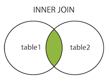

*INNER JOIN Syntax:*

```
/*Inner Join example*/
SELECT column_name(s)
FROM table1
INNER JOIN table2
ON table1.column_name = table2.column_name;
```

**LEFT JOIN** keyword returns all records from the left table (table1), and the matched records from the right table (table2). The result is NULL from the right side, if there is no match.

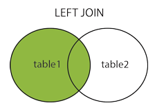

*LEFT JOIN Syntax:*

```
/*Left Join example*/
SELECT column_name(s)
FROM table1
LEFT JOIN table2
ON table1.column_name = table2.column_name;
```

**RIGHT JOIN** keyword returns all records from the right table (table2), and the matched records from the left table (table1). The result is NULL from the left side, when there is no match.

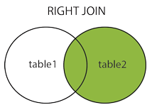

*RIGHT JOIN Syntax:*

```
/*Right Join example*/
SELECT column_name(s)
FROM table1
RIGHT JOIN table2
ON table1.column_name = table2.column_name;
```

**FULL OUTER JOIN** keyword returns all records when there is a match in left (table1) or right (table2) table records.

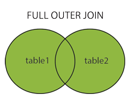

*FULL OUTER JOIN Syntax:*

```
/*Full Outer Join example*/
SELECT column_name(s)
FROM table1
FULL OUTER JOIN table2
ON table1.column_name = table2.column_name
WHERE condition;
```

```python
%%sql
--'INNER JOIN'
SELECT first_name, country
FROM employees INNER JOIN regions
ON employees.region_id = regions.region_id
LIMIT 10
```

```
 * postgresql://postgres:***@localhost/course_data
10 rows affected.
```

| first_name | country |
| --- | --- |
| Berrie | Asia |
| Aeriell | United States |
| Sydney | Asia |
| Avrom | Canada |
| Feliks | Asia |
| Bethena | United States |
| Ardeen | Canada |
| Seline | United States |
| Dayle | United States |
| Redford | Canada |

```python
%%sql
--'LEFT JOIN'
--'SEE only departments that exist employees but not in departments table'
SELECT DISTINCT employees.department, departments.department
FROM employees LEFT JOIN departments
ON employees.department = departments.department
WHERE departments.department IS NULL
```

```
 * postgresql://postgres:***@localhost/course_data
4 rows affected.
```

| department | department_1 |
| --- | --- |
| Camping | None |
| Maintenance | None |
| Plumbing | None |
| Security | None |

```python
%%sql
--'RIGHT JOIN'
SELECT DISTINCT employees.department, departments.department
FROM employees RIGHT JOIN departments
ON employees.department = departments.department
LIMIT 10
```

```
 * postgresql://postgres:***@localhost/course_data
10 rows affected.
```

| department | department_1 |
| --- | --- |
| Clothing | Clothing |
| Vitamins | Vitamins |
| Cosmetics | Cosmetics |
| None | Camping & Fishing |
| Books | Books |
| Sports | Sports |
| Children Clothing | Children Clothing |
| Device Repair | Device Repair |
| Furniture | Furniture |
| Games | Games |

```python
%%sql
--'FULL OUTER JOIN'
SELECT DISTINCT employees.department, departments.department
FROM employees FULL OUTER JOIN departments
ON employees.department = departments.department
LIMIT 10
```

```
 * postgresql://postgres:***@localhost/course_data
10 rows affected.
```

| department | department_1 |
| --- | --- |
| Clothing | Clothing |
| Vitamins | Vitamins |
| Cosmetics | Cosmetics |
| None | Camping & Fishing |
| Books | Books |
| Sports | Sports |
| Children Clothing | Children Clothing |
| Plumbing | None |
| Device Repair | Device Repair |
| Furniture | Furniture |

### UNION, UNION ALL, and EXCEPT clauses

The UNION operator is used to combine the result-set of two or more SELECT statements.

- Each SELECT statement within UNION must have the same number of columns
- The columns must also have similar data types
- The columns in each SELECT statement must also be in the same order

*UNION Syntax:*

```
/*UNION example*/
SELECT column_name(s) FROM table1
UNION
SELECT column_name(s) FROM table2;
```

The UNION operator selects only distinct values by default. To allow duplicate values, use UNION ALL:

*UNION ALL Syntax:*

```
/*UNION ALL example*/
SELECT column_name(s) FROM table1
UNION ALL
SELECT column_name(s) FROM table2;
```

EXCEPT takes first result set and removes all items found within second result set'

*EXCEPT Syntax:*

```
/*Except example*/
SELECT column_name(s) FROM table1
EXCEPT
SELECT column_name(s) FROM table2;
```

```python
%%sql
--'UNION removes duplicates before stacking'
--'UNION ALL does not remove duplicates before stacking'
SELECT department
FROM employees
UNION ALL
SELECT department
FROM departments
LIMIT 10
```

```
 * postgresql://postgres:***@localhost/course_data
10 rows affected.
```

| department |
| --- |
| Sports |
| Tools |
| Clothing |
| Phones & Tablets |
| Computers |
| Sports |
| Clothing |
| Phones & Tablets |
| First Aid |
| Clothing |

```python
%%sql
--'EXCEPT takes first result set and removes all items found within second result set'
SELECT department
FROM employees
EXCEPT
SELECT department
FROM departments
```

```
 * postgresql://postgres:***@localhost/course_data
4 rows affected.
```

| department |
| --- |
| Camping |
| Maintenance |
| Plumbing |
| Security |

###### Creating Views

```python
%%sql
--'Creating v1_employee_information View'
CREATE VIEW v1_employee_information as
SELECT first_name, email, e.department, salary, division, region, country
FROM employees e, departments d, regions r
WHERE e.department = d.department
AND e.region_id = r.region_id
```

```
 * postgresql://postgres:***@localhost/course_data
Done.
```

```
[]
```

```python
%%sql
--'Calling the view from above'
SELECT * FROM v1_employee_information LIMIT 10
```

```
 * postgresql://postgres:***@localhost/course_data
10 rows affected.
```

| first_name | email | department | salary | division | region | country |
| --- | --- | --- | --- | --- | --- | --- |
| Berrie | bmanueau0@dion.ne.jp | Sports | 154864 | Outdoors | Central | Asia |
| Aeriell | amcnee1@google.es | Tools | 56752 | Hardware | Northwest | United States |
| Sydney | ssymonds2@hhs.gov | Clothing | 95313 | Home | Central | Asia |
| Avrom | None | Phones & Tablets | 119674 | Electronics | Nova Scotia | Canada |
| Feliks | fmorffew4@a8.net | Computers | 55307 | Electronics | East Asia | Asia |
| Bethena | btrow5@technorati.com | Sports | 134501 | Outdoors | Northwest | United States |
| Ardeen | acurwood6@1und1.de | Clothing | 28995 | Home | Nova Scotia | Canada |
| Seline | sdubber7@t-online.de | Phones & Tablets | 101066 | Electronics | Northwest | United States |
| Dayle | dtrail8@tamu.edu | First Aid | 82753 | Health | Southwest | United States |
| Redford | None | Clothing | 72225 | Home | Nova Scotia | Canada |

## Window Functions for Analytics

A window function performs a calculation across a set of table rows that are somehow related to the current row. This is comparable to the type of calculation that can be done with an aggregate function. But unlike regular aggregate functions, use of a window function does not cause rows to become grouped into a single output row — the rows retain their separate identities. Behind the scenes, the window function is able to access more than just the current row of the query result.

Reference: https://www.postgresql.org/docs/9.1/tutorial-window.html

```python
%%sql
--'Count of employees by department using Window Functions'
SELECT
    first_name,
    department,
    COUNT(*) OVER(PARTITION BY department)
FROM employees
ORDER BY first_name
LIMIT 10
```

```
 * postgresql://postgres:***@localhost/course_data
10 rows affected.
```

| first_name | department | count |
| --- | --- | --- |
| Abbot | Movies | 56 |
| Abbott | Automotive | 32 |
| Abby | Jewelry | 41 |
| Adam | Sports | 34 |
| Addia | Grocery | 28 |
| Addy | Toys | 47 |
| Adelaida | Movies | 56 |
| Adelaide | Toys | 47 |
| Adrian | Music | 29 |
| Adrianna | First Aid | 58 |

```python
%%sql
--'Rank Salaries by department using Window Functions'
SELECT
    first_name,
    email,
    department,
    salary,
    RANK() OVER(PARTITION BY department ORDER BY salary DESC)
FROM employees
LIMIT 10
```

```
 * postgresql://postgres:***@localhost/course_data
10 rows affected.
```

| first_name | email | department | salary | rank |
| --- | --- | --- | --- | --- |
| Mill | None | Automotive | 162522 | 1 |
| Irita | istarie2h@answers.com | Automotive | 160783 | 2 |
| Tammie | None | Automotive | 160039 | 3 |
| Roslyn | rguiu3h@com.com | Automotive | 157260 | 4 |
| Betsey | breedshawc5@phoca.cz | Automotive | 152141 | 5 |
| Cherianne | None | Automotive | 150821 | 6 |
| Chrissy | cappletonlq@census.gov | Automotive | 146522 | 7 |
| Poppy | plinesn7@gmpg.org | Automotive | 144511 | 8 |
| Cy | cmenceft@icq.com | Automotive | 144146 | 9 |
| Jilleen | None | Automotive | 137393 | 10 |

```python
%%sql
--'NTILE Salaries by department using Window Functions'
SELECT
    first_name,
    email,
    department,
    salary,
    NTILE(5) OVER(PARTITION BY department ORDER BY salary DESC)
FROM employees
LIMIT 10
```

```
 * postgresql://postgres:***@localhost/course_data
10 rows affected.
```

| first_name | email | department | salary | ntile |
| --- | --- | --- | --- | --- |
| Mill | None | Automotive | 162522 | 1 |
| Irita | istarie2h@answers.com | Automotive | 160783 | 1 |
| Tammie | None | Automotive | 160039 | 1 |
| Roslyn | rguiu3h@com.com | Automotive | 157260 | 1 |
| Betsey | breedshawc5@phoca.cz | Automotive | 152141 | 1 |
| Cherianne | None | Automotive | 150821 | 1 |
| Chrissy | cappletonlq@census.gov | Automotive | 146522 | 1 |
| Poppy | plinesn7@gmpg.org | Automotive | 144511 | 2 |
| Cy | cmenceft@icq.com | Automotive | 144146 | 2 |
| Jilleen | None | Automotive | 137393 | 2 |

```python
%%sql
--'First Value Salaries by department using Window Functions'
SELECT
    first_name,
    email,
    department,
    salary,
    FIRST_VALUE(salary) OVER(PARTITION BY department ORDER BY salary DESC)
FROM employees
LIMIT 10
```

```
 * postgresql://postgres:***@localhost/course_data
10 rows affected.
```

| first_name | email | department | salary | first_value |
| --- | --- | --- | --- | --- |
| Mill | None | Automotive | 162522 | 162522 |
| Irita | istarie2h@answers.com | Automotive | 160783 | 162522 |
| Tammie | None | Automotive | 160039 | 162522 |
| Roslyn | rguiu3h@com.com | Automotive | 157260 | 162522 |
| Betsey | breedshawc5@phoca.cz | Automotive | 152141 | 162522 |
| Cherianne | None | Automotive | 150821 | 162522 |
| Chrissy | cappletonlq@census.gov | Automotive | 146522 | 162522 |
| Poppy | plinesn7@gmpg.org | Automotive | 144511 | 162522 |
| Cy | cmenceft@icq.com | Automotive | 144146 | 162522 |
| Jilleen | None | Automotive | 137393 | 162522 |

```python
%%sql
--'nth Value Salaries by department using Window Functions'
SELECT
    first_name,
    email,
    department,
    salary,
    NTH_VALUE(salary, 5) OVER(PARTITION BY department ORDER BY salary DESC)
FROM employees
LIMIT 10
```

```
 * postgresql://postgres:***@localhost/course_data
10 rows affected.
```

| first_name | email | department | salary | nth_value |
| --- | --- | --- | --- | --- |
| Mill | None | Automotive | 162522 | None |
| Irita | istarie2h@answers.com | Automotive | 160783 | None |
| Tammie | None | Automotive | 160039 | None |
| Roslyn | rguiu3h@com.com | Automotive | 157260 | None |
| Betsey | breedshawc5@phoca.cz | Automotive | 152141 | 152141 |
| Cherianne | None | Automotive | 150821 | 152141 |
| Chrissy | cappletonlq@census.gov | Automotive | 146522 | 152141 |
| Poppy | plinesn7@gmpg.org | Automotive | 144511 | 152141 |
| Cy | cmenceft@icq.com | Automotive | 144146 | 152141 |
| Jilleen | None | Automotive | 137393 | 152141 |

```python
%%sql
--'LAG Salaries by department using Window Functions'
SELECT
    first_name,
    email,
    department,
    salary,
    LAG(salary) OVER(PARTITION BY department ORDER BY salary DESC)
FROM employees
LIMIT 10
```

```
 * postgresql://postgres:***@localhost/course_data
10 rows affected.
```

| first_name | email | department | salary | lag |
| --- | --- | --- | --- | --- |
| Mill | None | Automotive | 162522 | None |
| Irita | istarie2h@answers.com | Automotive | 160783 | 162522 |
| Tammie | None | Automotive | 160039 | 160783 |
| Roslyn | rguiu3h@com.com | Automotive | 157260 | 160039 |
| Betsey | breedshawc5@phoca.cz | Automotive | 152141 | 157260 |
| Cherianne | None | Automotive | 150821 | 152141 |
| Chrissy | cappletonlq@census.gov | Automotive | 146522 | 150821 |
| Poppy | plinesn7@gmpg.org | Automotive | 144511 | 146522 |
| Cy | cmenceft@icq.com | Automotive | 144146 | 144511 |
| Jilleen | None | Automotive | 137393 | 144146 |

```python
%%sql
--'LEAD Salaries by department using Window Functions'
SELECT
    first_name,
    email,
    department,
    salary,
    LEAD(salary) OVER(PARTITION BY department ORDER BY salary DESC)
FROM employees
LIMIT 10
```

```
 * postgresql://postgres:***@localhost/course_data
10 rows affected.
```

| first_name | email | department | salary | lead |
| --- | --- | --- | --- | --- |
| Mill | None | Automotive | 162522 | 160783 |
| Irita | istarie2h@answers.com | Automotive | 160783 | 160039 |
| Tammie | None | Automotive | 160039 | 157260 |
| Roslyn | rguiu3h@com.com | Automotive | 157260 | 152141 |
| Betsey | breedshawc5@phoca.cz | Automotive | 152141 | 150821 |
| Cherianne | None | Automotive | 150821 | 146522 |
| Chrissy | cappletonlq@census.gov | Automotive | 146522 | 144511 |
| Poppy | plinesn7@gmpg.org | Automotive | 144511 | 144146 |
| Cy | cmenceft@icq.com | Automotive | 144146 | 137393 |
| Jilleen | None | Automotive | 137393 | 137094 |